# Five Year Plans in India

## Reference

- http://mospi.gov.in/sites/default/files/Statistical_year_book_india_chapters/ch7.pdf
- Ch 7

## History of Planning

- Inception of plannning in 1951
- Planned Economic Development path
- Theoretical efforts began much ealier
  - 1938: National Planning Committee
  - 1944: The Bombay Plan and the Gandhian Plan
  - 1945: People’s Plan
  - 1950: Sarvodaya Plan
- FYPs are centralised and integrated economic programmes.
- First FYP was implemented in the Soviet Union in 1920s.
- Planning Commission in India was established in March 1950.
  - Raise the standard of living
  - Increase production and employment opportunities
- 1951: 1st FYP
- 1966-69: 3 annual plans
  - Droughts, Indo-Pak war and devaluation
- 1969: 4th FYP
- 1990-91 & 1991-92: 2 Annual Plans
  - Fast changing political situation in the centre
- 1992: 8th FYP

## 1st FYP (1951-56)

- Target: 2.1% Achieved: 3.6%
- Based on Harrod-Domar growth model
  - Keynesian model of economic growth
  - Output = Savings \(\times\) marginal product of capital \(-\) depreciation
- Influx of refugees
- Food shortage and mounting inflation
- Focus on agriculture, price stability & power and transport.
- A successful plan
  - Good monsoon leading to good harvest
  - Rehabilitation of refugees, food sufficiency and price controls.

## 2nd FYP (1956-61)

- Target: 4.5% Achieved: 4.3%
- Harrod-Domar Model + Mahalanobis Strategy
- Less priority to agriculture
- Focus on rapid industrialisation
- Acute shortage of forex
- Modestly successful plan

## 3rd FYP (1961-66)

- Target: 5.6% Achieved: 2.8%
- Belief that the economy had entered the “take-off stage”.
- Aim: Self reliant and self generating
- Importance to agriculture
- A complete failure
  - Chinese Agression (1962)
  - Indo-Pak War (1965)
  - Droughts (1965-66)
- Shift in the focus: from *development* to *defence and development*.

## 3 Annual Plans (1966-69)

- Plan holiday
- Devaluation & inflation led to postponement of the 4th FYP.
- Emphasis on the agri sector
- Agri strategy
  - HYV seeds, fertilizers, irrigation and soil conservation
- Absorbed the shocks generated during the 3rd PFY
- Paved a path for planned growth ahead.

## 4th FYP (1969-74)

- Target: 5.7% Achieved: 3.3%
- Objectives:
  - Growth with stability
  - Progressive achievement of self reliance.
- Emphasis on agriculture \(\rightarrow\) other sectors.
- Implementation of Family Planning Programmes

## 5th FYP (1974-79)

- Target: 4.4% Achieved: 4.8%
- Objectives
  - *Garibi hatao*
  - Attainment of self reliance
- Janata party came to power in 1978
  - Launch of the 6th FYP (1978-83)
  - Emphasis on employment
- Congress government comes to power in 1980
  - Launch of another plan in 1980

## 6th FYP (1980-85)

- Focus on increasing national income
- Modernisation of technology
- TRYSEM (Training of Rural Youth for Self Employment)
- NREP (National Rural Employment Programme)
- IRDP (Integrated Rural Development Programme)
- growth: 5.7%

## 7th FYP (1985-90)

- Growth : 6%
- Accelerated food grain production and employment

## 8th FYP (1992-97)

- Introduction of liberalisation
- Outcomes:
  - Rapid economic growth 6.8%
  - Growth of manufacturing sector
  - Improvement in CAD and trade

## 9th FYP (1997-2002)

- Target: 6.5% Achieved: 5.4%
- Growth with Social Justice and Equality
- Increasing role of the private sector
- Priority to agriculture and rural development

## 10th FYP (2002-2007)

- Target: 8% Achieved: 7.6%
- Reduction in gender gaps, and mortality rates
- Access to drinking water
- Focus on Panchayati Raj Institutions
- One of the fastest growing economies

## 11th FYP (2007-12)

- Target: 9% Achieved: 8%
- Focus on the *Aam Aadmi*
- FDI, savings and investments at all time high
- Growth not inclusive for SC/ST and minorities
- NREGP (National Rural Employment Guarantee Programme)
- Global Financial Crisis (2008)
- Sovereign Debt Crisis (2011)

## 12th FYP (2012-17)

- Eurozone Crisis
- Growth declined to 5%
- Vision: Faster, Sustainable and more inclusive growth

## Studying the Planning Commission (1950-2014)

## Reference

Mehrotra, S and Guichard, S (2020) *Plannning in the 20th Century and Beyond: India’s Planning Commission and the NITI Aayog* Cambridge University Press Chapter 2: From Economists to Historians: Studying the Planning Commission, 1950–2014

## The Planning Commission (PC) as an institution

  > The Planning Commission became the exclusive theatre where economic policy was formulated. The subject was removed from parliament and the cabinet – they were now merely informed of decisions taken by the small cohort of experts. The members of the Planning Commission were by no means all economists, but they were chosen by Nehru for their broad agreement with his political project: committed to ‘socialistic’ and reformist ideals, in the Indianized version of social democracy, and above all to a scepticism about the market and a belief that the state had to take responsibility for allocating resources in the economy. (Khilnani 1997: 85–86)
- IN 1950, [K.N. Raj](https://en.wikipedia.org/wiki/K._N._Raj) (at the age of 26) was the only professional economist in the PC (Krishnakumar 2010).
- The sanctioned staff strength increased from 244 in 1951-52 to 1,131 in 1963-64.
- The expenditure increased from INR 8.65 lakhs in 1950-51 to INR 59.90 lakhs in 1963-64.
- The staff strength remained nearly the same when the PC was dissolved in 2015.

## Studying the PC over the decades

**1950 to 1965: Questioning techniques**

- The PC was founded with an idea of the time
  - International agreement on the need for planning

> in tune with the intellectual ambiance of the period which in turn reflected the state of the international economy. The Great Depression of the inter-war period had destroyed any faith in the virtues of the free market, and Keynesianism … advocated not just state intervention in demand management in capitalist economies, but the necessity of socializing investment decisions. ([Prabhat Patnaik](https://en.wikipedia.org/wiki/Prabhat_Patnaik) 1998: 159–160)
- Soviet Union was free from the ravages of the Depression and was experiencing high growth rates which were unprecedented in human history.

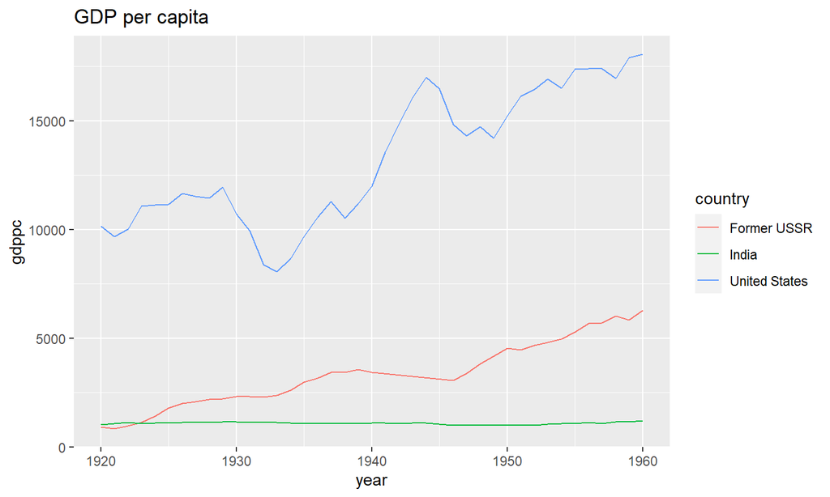

Source: [Maddison Project Database 2020](https://www.rug.nl/ggdc/historicaldevelopment/maddison/releases/maddison-project-database-2020)

- The scholars writing on planning in the 1950s did not question the idea or the necessity of planning.
- Their research was about **How best to plan?** or **What sort of planing?**

  > ‘the goal of development was growth: the agent of development was the state and the means of development were national economic planning in the context of macro-policy instruments established at Bretton Woods.’
- The goal of planning was to promote social equality by increasing real per capita incomes.
- The real question was **how best to do that**?
- Most of the studies focused on **the choices made**, **the models**, **the techniques** and their **efficiency**.

**1960s and 1970s: Questioning Processes, Actors, and Interests**

- The PC was the most powerful during this decade.
- A lot of studies were done.
- In the 1960s, many observers in India and abroad were full of praise for the work of the PC.
- Lewis (1963: 80) wrote that

  > Indian economic planning has – and probably deserves – the reputation of being the most experienced, sophisticated, and comprehensive of any in the non-Communist economically underdeveloped world.
- However, the praise was not unanimous.
- [D. R. Gadgil](https://en.wikipedia.org/wiki/Dhananjay_Ramchandra_Gadgil) in a lecture in 1958 considers that the PC has failed in every function

  > ‘to assess resources, formulate the plan, define its stages, appraise progress, and make related recommendations on policy and administration’ (lecture republished in Gadgil 1965: 150–172, 169)
- After 10 years of planning, many scholars seemed also disappointed with the results attained and disillusioned with planning.
- Economists diagnosed a crisis in planning in general (Faber and Seers 1972) and in India in particular (Hanson 1966; Streeten and Lipton 1968; Namboodiripad 1974).
- From then on, they questioned the usefulness of planning.
- At the end of the 1960s, the specific choices made in India were re-examined as well: **why did Indian planning focus on state-owned heavy industry at the expense of other sectors, most importantly agriculture but also education?**
- Answers:
  - Economic reasons like **export pessimism** and **foreign exchange constraint** (Raj and Sen 1961; Dhar 1968; Bhagwati and Chakravarty 1969).
  - Nehru’s fervent commitment and belief in socialism (Frankel 1967, see also Schöttli 2009).
- In the 1970s, criticisms came from all sides: it came, as could be expected, *from scholars in favour of a liberal economic policy and sceptical about planning from the beginning*, but also from *scholars who supported planning after independence, people who wanted a socialist economy* but observed that planning had not brought the expected results.
- For instance [B.R. Shenoy](https://swarajyamag.com/economy/b-r-shenoy-a-forgotten-economist-and-what-modi-can-learn-from-him) (author of the book *Note of Dissent to the Second Five-year Plan* in 1955) was one of the **sceptics from the beginning** wrote:

  > ‘There is a great need for a basic policy shift from statist planning to policies of economic liberalism.’ (Shenoy 1963: vi).
- Along the same line, Jagdish Bhagwati, Padma Desai, and T. N. Srinivasan, who **at first supported planning after independence, turned against it in the 1970s** and advocated a new liberalized economic policy.
- Leys (1996) summarizes (roughly) the position of this ‘small group of economists who opposed the postwar-social-democratic consensus’.
- He notes that

  > India’s foreign trade regime, in conjunction with domestic licensing policies in the industrial sector, led to economic inefficiencies and impaired her economic performance.… The policy framework was detrimental, on balance, to the growth of the economy by adversely influencing export performance, by wasteful interindustrial and inter-firm allocation of resources, by permitting and encouraging expansion of excess capacity and by blunting competition and hence the incentives for cost-consciousness and quality-improvement. The effects on savings and research and development expenditures were, at best, ambiguous and cannot plausibly be cited as having offset these inefficiencies. (Bhagwati and Srinivasan 1974: 245)
- In the 1970s, criticisms grew as well concerning the place given to agriculture (Frankel 1978).
- Mellor (1976) and Lipton (1977) proposed a new path of growth led by agriculture and based on the improvement of agriculture on the mass of small farms.
- Beyond being in favour of, against, or disappointed by planning, the way to look at planning changed in the mid-1960s.
- Economists in the 1950s wrote on planning from a technical economic point of view.
- Ten years later, political scientists and economists argued that to understand how planning works it is necessary to consider political, social, institutional, and economic forces.
- In consequence, they adopted wider views asking **‘Who plays a role, who sets the goals?’**

**1980s: Questioning the State and Planning**

- The 1980s saw a **‘shift from planning the economy to management of the economy’** (Kurien 1996: 10) to **‘freeing the economy’** as the subtitle of Jagdish Bhagwati’s book *India in Transition (1993)* indicates.
- During the 1980s, economists continued to assess how successful planning had been in furthering the development of the country (Gupta [1989] ,[Sukhamoy Chakravarty](https://en.wikipedia.org/wiki/Sukhamoy_Chakraborty) [1987]).
- Byres (a Marxist economist) considers that the literature

  > ‘presented a virulent critique of planning, which was represented as simply the institutionalised means whereby the state pursued its predation, extended and reproduced its massive inefficiencies, and gave rise to growing and deeply entrenched rent seeking’ (Byres 1997a: 1)
- Political scientists and political activists also examined whether the Indian state’s policies, actions, and structures perpetuated or challenged class-based inequalities.
- Their work contributes to broader discussions about social justice, governance, and the distribution of power and resources within the country.
- The discussion among economists on the role played by the Indian state in fostering development has focused on the sluggish growth rate of the economy since the mid-1960s.
- Political scientists accepted these viewpoints and combined them with considerations on the nature and distribution of power and influence in the Indian society.

**1990s: Questioning the Institution, Its Adaptability**

- The 1990s saw two main types of studies on planning and the PC:
  - One considers how planning and the PC have changed/adapted following the liberalization of the Indian economy;
  - another follows the theme of ‘planning and the state’, looking either at planning and the bureaucratic state or at planning and nationalism.

**Liberalization**

- A large amount of literature ‘sympathetic to the reforms’.
- Also some critical treatment of the reforms (Rudra 1992; Byres 1997b; see Byres 1997a).
- However, the vast majority of these works was not on the PC and not really on planning; they were on liberalization (and only indirectly on its impacts on planning).
- Nevertheless, some research considered directly how planning and the PC have changed or adapted following the liberalization of the Indian economy, what were their remaining role and how they should transform themselves .
- Studies set out to evaluate anew the achievements and limitations of Indian planning between 1950 and the late 1980s.
- For instance: **‘who has benefitted from planning?’**
- The answer was that planning ‘was meant to’ and benefited mostly rich farmers through its agricultural policy and industrial capitalists through its industrialization policy (even if he is more uncertain about the second group, see 1998: 111). He concludes that ‘the major indictment of planning in India is that it failed to benefit the poor’ (Chaudhuri 1998: 111)

**Planning and State**

- In the 1990s, scholars pursued the analysis of the link between planning and the (bureaucratic) state (Bardhan 1998; Chatterjee 1997; Byres 1997a; Kaviraj 1995; Nayar 1997).
- This literature developed in the 1990s but it is looking back.
- Its focus was on the 15 years after independence when the PC was a strong institution.
- It examined the role of planning in conjunction with the type of state built after independence and emphasized that planning appeared as a necessity after the promises made during the independence struggle.
- [Partha Chatterjee](https://anthropology.columbia.edu/content/partha-chatterjee) in his oft-quoted article addressing the political role of planning in India considers that

  > the debate on the need for industrialisation … was politically resolved by successfully constituting planning as a domain outside the ‘squabbles and conflicts of politics’. As early as the 1940s, planning had emerged as a crucial institutional modality by which the state would determine the material allocation of productive resources within the nation: a modality of political power constituted outside the immediate political process itself. (Chatterjee 1997: 275–276)
- According to other scholars, the main intent of adopting planning was not to build *socialism* but to build capitalism on behalf of the bourgeoisie.
- According to Patnaik (1994);

  > ‘the class-configuration which prevailed, upon which industrial capitalism was to develop, dictated in broad terms a certain course of action, and the Mahalanobis strategy fitted in with this’.

**2000s: Re-questioning the Beginnings**

- Review of planning’s achievements or failures continued.
- This led to a rise in the debates on the obsolescence of *planning* and the *PC*.
- The economist Amaresh Bagchi (2007) asks *if there is a role for centralized planning in a market economy such as the one of India after liberalization?*
  - Centralized planning according to him is needed:

    > The reason is twofold. One, when resources happen to be limited – and that lies at the heart of the economic problem of choice – given the objectives, actions must be guided by a well-designed plan.… Two, it has to be recognised that even in a market economy that state has to play a vital role as a facilitator but also as a provider of basic infrastructure, fiscal, social and financial. (Bagchi 2007: 93)
- Bagchi (2007: 93) underlines the necessity to reform three practices:
  1. ‘the practice of classifying expenditures in government budget under “plan and non-plan”’;
  2. ‘inadequate fiscal space of the states for fulfilling the objectives of the plans while major responsibilities for plan implementation are devolved on them’; and
  3. ‘the system of intergovernmental transfers that is supposed to help address one of the basic objectives of planning, i.e. balanced regional growth’.
- There was also criticisms which were not against planning in general but on how planning was done and implemented.
- In the 1960s, many studies appeared describing the status of the commission, its aim, and its organizational arrangements.
- They often emphasized that planning had to deal with important limitations:
  - the fact that most of India’s economy was in private hands (Hanson 1966: 3) or ‘controlled by [a] small, group of high capitalists’ (Gadgil 1965: 284),
  - that planning was prepared by the centre but had to be implemented by the states (Lewis 1963), and
  - that planning was too centralized.
- These elements greatly diminished the planning grip, the first mainly in the drawing of the plan and the last two in its implementation (Lewis 1963: 108).

## Plan, But Do Not Over Plan: Lessons for NITI Aayog

## Reference

Mehrotra, S and Guichard, S (2020) *Plannning in the 20th Century and Beyond: India’s Planning Commission and the NITI Aayog* Cambridge University Press Chapter 13: Plan, But Do Not Over Plan: Lessons for NITI Aayog

## The Planning Experience in India

- Devolution of the Planning Commission & replacement with NITI Aayog
- Narendra Modi’s speech on 15 Aug 2014
- GOI announces the formation of NITI aayog on 1 January 2015.
- Old style central planning out and new style reform agenda was in.
- A market-led process of growth and development
- Develop and 15 year vision, 7 year strategy and 3 year implementation framework.
- The 1st FYP was an agenda and not a plan
- Limitations during the 2nd FYP
  - savings, growth theories
- Original concept of Mahalanobis and Nehru
- Belief in the technocrats.
- A phased reduction of the savings constraint.
- The 3rd FYP conceived during a period of emerging BoP crisis
- A new constraint evolves: foreign exchange
- Two ways to address this crisis:
  - Increase exports
  - Reduce imports
- Would derail the strategy of increasing savings and long-run productivity.
- The 3rd FYP introduced Import Substitution Policy
- Partly political and partly technocratic.
- Received considerable attention and acclaim from politicians, academicians, and policymakers.
- 2 important developments:
  - Decentralised Planning
  - Detailed sectoral planning
- The 4th FYP was implemented amidst droughts, famines, and wars.
- Food security at the forefront of planning.
- Sustained industrialisation not possible without wage-goods.
- A third constrained introduced: wage-goods
- The 5th FYP recognised that growth and industrialisation alone would not eradicate poverty.
- Echoed in the slogan *Garibi Hatao*
- An extra element to the objectives of the plan.
  - Concept of *minimum needs*
  - Directed anti-poverty programmes.
- The 6th FYP recognised the successess of the Mahalanobis model
  - The savings constraint was now no longer binding.
  - Excess capacities created
- A shift in the pattern of industrialisation.
- Shift towards a more technocratic planning.
- The 7th FYP was an *infrastructure* plan.
- Shift to liberal trading regimes.
- Strategic planning by the political leadership
- The 8th FYP saw the economic crisis of 1991.
- Market-oriented planning
- Economy performed well
- The growth momentum could not be carried to the 9th FYP.
- 9th FYP recognised the importance of private investment.
- Added a fourth constraint: the financial constraint.
  - A weak financial sector can deprive the economy of optimal utilisation of the resources.
- Fiscal policy brought under the planning ambit.
- The Fifth Pay Commission weakened investment.
- Agriculture failure + Tight monetary policy also weakened investment
- The 10th FYP was a visionary plan.
- Emerging situation of demographic pattern
- Steady reduction in the rate of growth of population in India, but a high growth of working age population.
- Challenges:
  - Provide employment opportunities to this fast growing population.
  - Address the spatial pattern of creating jobs.
- Strong public intervention required in the infrastructure.
- Insights from the 10th FYP seen in the 11th FYP
- Inclusive growth
- Unemployment and infrastructure
- Human resources
- Growth 9%
  - Shortages of *skills*.
- The Global Financial Crisis 2008 & Eurozone Crisis 2011
- Drought in 2009
- 12th FYP: Lost growth momentum
- Slowing down of corporate investment
- Efforts to revive private investment sentiments
- National Institution for Transforming India (2015)
- Mandate of the NITI Aayog
  - Framing the vision by the technocrats
- Indian experience
  - Framing vision by the political class have been relatively successful.
  - The 2nd to 5th FYPS and the 10th FYP have had political visions (implemented at the technocrat levels).
  - No good strategic planning can occur in the absence of a challenging and well articulated vision.
- 3 critical characteristics of a vision statement:
  - Capture the imagination of the nation.
  - Full political commitment.
  - Thinking beyond mere extrapolations.
- On this count, NITI has been started on a wrong foot.